# R Notebook

# Input

```r
rw.merge <- read.csv("C:\\Users\\tenni\\OneDrive\\Documents\\GitHub\\r_w_project\\data\\rw_merge.csv")
acous <- read.csv("C:\\Users\\tenni\\OneDrive\\Documents\\GitHub\\r_w_project\\data\\acoustic.csv")
```

child age

```r
acous$ChildAge <- as.numeric(substr(acous$ChildID, start=5, stop=6))
rw.merge$ChildAge <- as.numeric(substr(rw.merge$ChildID, start=5, stop=6))
```

libraries

# F2F3 for R and W

How to scale? - Account for age - scale F3 F2 separately, then calculate their difference

How should we account for age?

## f2 by age for /r/ and /w/

```
longer object length is not a multiple of shorter object length
```

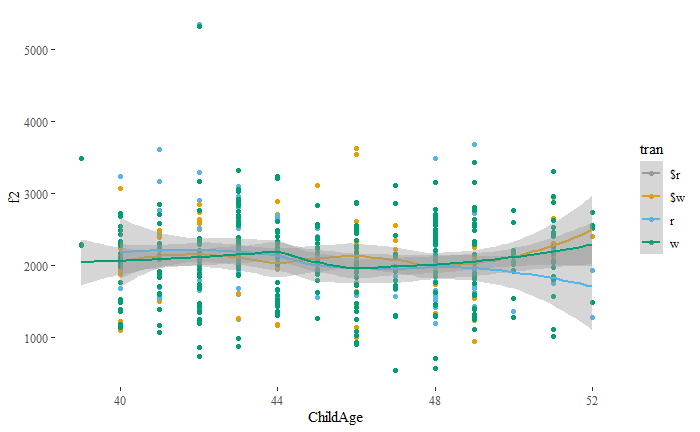

```r
ggplot(
  data=(acous %>% filter(
    tran == c("$r", "r", "$w", "w")
  )),
  aes(y=f2, x=ChildAge, color=tran)
) +
  scale_colour_manual(values=cbPalette) + theme_tufte()+
  geom_point()+
  geom_smooth(method=loess)
```

## f3 by age for /r/ and /w/

```
longer object length is not a multiple of shorter object length
```

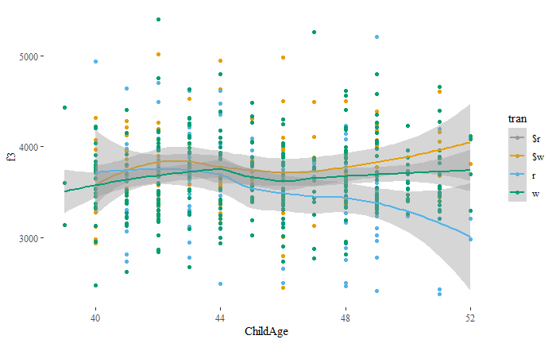

```r
ggplot(
  data=(acous %>% filter(
    tran == c("$r", "r", "$w", "w")
  )),
  aes(y=f3, x=ChildAge, color=tran)
) +
  scale_colour_manual(values=cbPalette) + theme_tufte()+
  geom_point()+
  geom_smooth(method=loess)
```

The f3 drops for r, its like a refinement. Or for younger kids there’s a contributor, or a proxy, or another cue.

Is the other cue vowels?

### f3 by age for /r/ by vowel

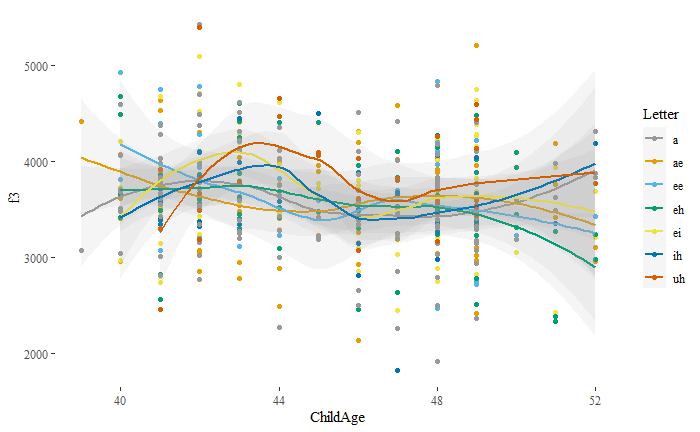

```r
ggplot(
  data=(acous %>% filter(
    tran == c("r")
  )),
  aes(y=f3, x=ChildAge, color=Letter)
) +
  scale_colour_manual(values=cbPalette) + theme_tufte()+
  geom_point()+
  geom_smooth(method=loess, alpha=.1)
```

Nope.

## f3f2 difference by age for /r/

```
longer object length is not a multiple of shorter object length
```

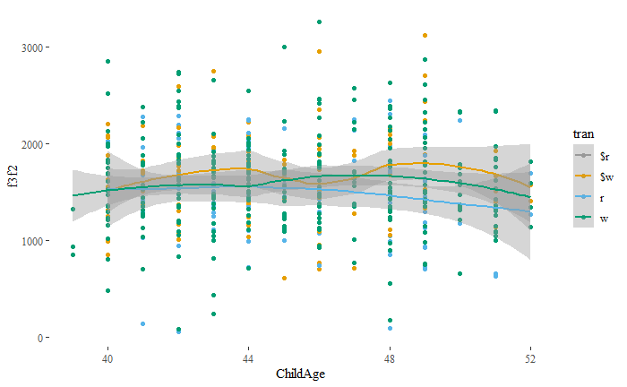

```r
ggplot(
  data=(acous %>% filter(
    tran == c("$r", "r", "$w", "w")
  )),
  aes(y=f3f2, x=ChildAge, color=tran)
) +
  scale_colour_manual(values=cbPalette) + theme_tufte()+
  geom_point()+
  geom_smooth(method=loess)
```

## scaled f2f3 by transcription

```
longer object length is not a multiple of shorter object length
```

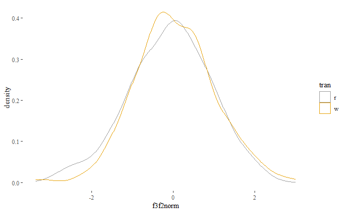

```r
ggplot(
  data=(acous %>% filter(
    #ChildID == unique(acous$ChildID)[22],
    tran == c("w", "r")
  )),
  aes(x=f3f2norm, color=tran)
) +
  geom_density() +
    scale_colour_manual(values=cbPalette) + theme_tufte()
```

# Adult Listener Ratings

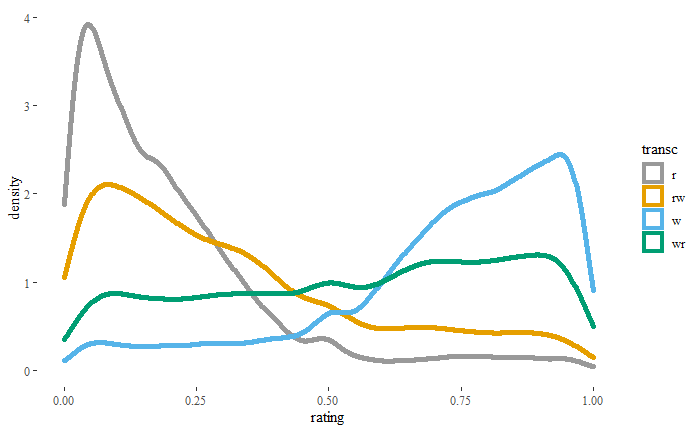

```r
ggplot(data=rw.merge, aes(x=rating, color=transc))+geom_density(size=2)+
  scale_colour_manual(values=cbPalette) + theme_tufte()
```

The wr line is really flat … which means the adult listeners ratings of wr transcriptions is … suspect/unreliable.

You have w’s, and you have r’s, and if you have even a little bit of rhoticity, then people perceive it towards the /r/ side. /r/ bias.

Need to check the method of transcription here, as there’s some debate about how to group the transcriptions. People may perceive this is just R, W, or a half r, with some rhoticity but not full on. What does “wr” mean?

R makes sense. W makes sense. RW also makes sense. It’s an R with a pinch of W. People aren’t quite as sure with RW as the R, but it’s pretty R like. The professional said this is neither r nor w but more r like, but the adult rates pushed them strongly towards R, but not fully so.

## Target R/W and Produced R/W

Adult rating by transcription by target word

$r is target w but sounds like r $w is target r but sounds like w

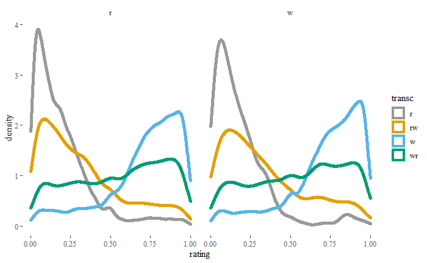

```r
ggplot(data=(rw.merge %>% filter(!is.na(target))), aes(x=rating, color=transc))+geom_density(size=2)+
  scale_colour_manual(values=cbPalette) + theme_tufte()+
facet_wrap(~target)
```

No differences by target word.

Is there a difference between r and $r? or w and $w? or r and $w vs. w and $r?

```
longer object length is not a multiple of shorter object length
```

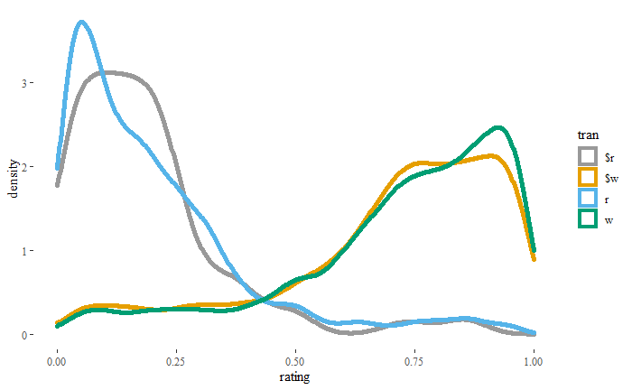

```r
ggplot(data=(rw.merge %>% filter(!is.na(target), tran == c("$r", "r", "$w", "w"))), aes(x=rating, color=tran))+geom_density(size=2)+
  scale_colour_manual(values=cbPalette) + theme_tufte()
```

This speaks to what Ben was investigating in his paper - is there a hidden difference in r productions based on target words? Maybe ever so slightly.

Is there a difference in $r by age?

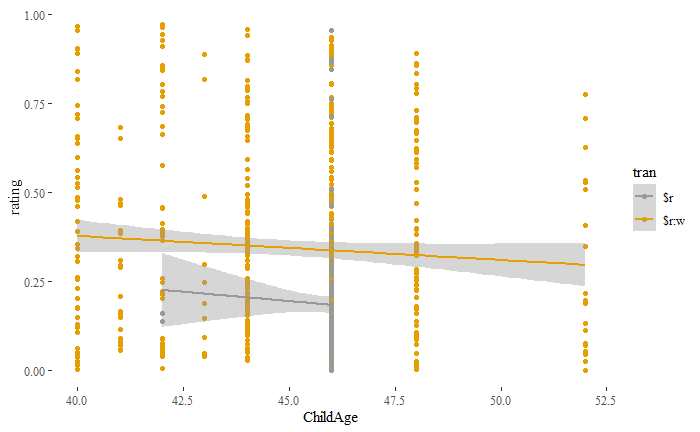

```r
ggplot(data=(rw.merge %>% filter(!is.na(target), tran == c("$r", "$r:w"))), aes(x=ChildAge, y=rating, color=tran))+
  geom_point()+geom_smooth(method=lm)+
  scale_colour_manual(values=cbPalette) + theme_tufte()
```

Is there a difference in $w by age?

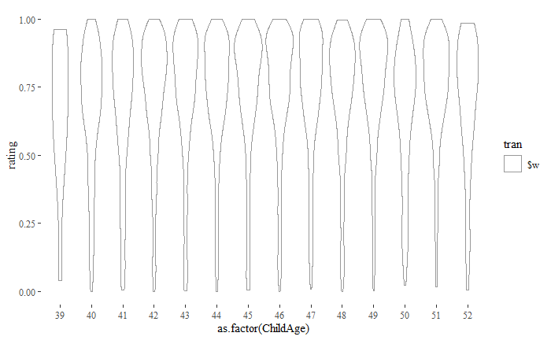

```r
ggplot(data=(rw.merge %>% filter(!is.na(target), tran == c("$w"))), aes(x=as.factor(ChildAge), y=rating, color=tran))+
#  geom_point()+geom_smooth(method=lm)+
  geom_violin()+
  scale_colour_manual(values=cbPalette) + theme_tufte()
```

No. It seems age is only helpful when considering within subject development, not across all participants in a single time point study.

## F3F2 distance and Rating

Contour plots for f3f2 distance and rating by transcription.

We’re expecting ratings to change as f3f2 changes, i.e., some non-zero slope on the central axis.

```
Removed 1181 rows containing non-finite values (stat_density2d).Removed 415 rows containing non-finite values (stat_density2d).Removed 104 rows containing non-finite values (stat_density2d).Removed 496 rows containing non-finite values (stat_density2d).
```

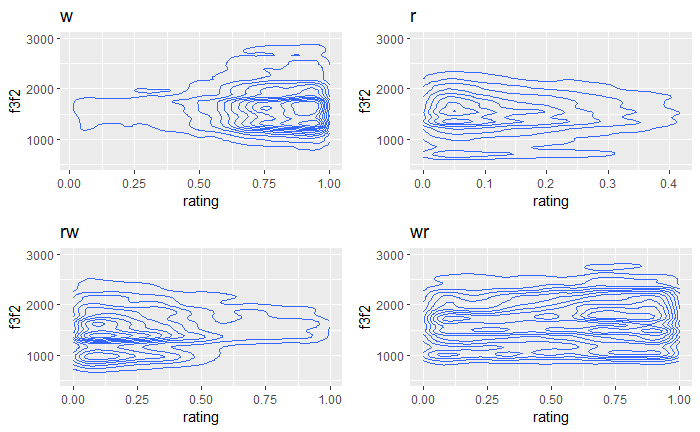

```r
p1=ggplot(data=(rw.merge %>% filter(transc=="w")), aes(y=f3f2, x=rating)) +
  labs(title="w") +
  geom_density_2d() +
  scale_y_continuous(limits=c(500,3000))

p2=ggplot(data=(rw.merge  %>% filter(transc=="r")), aes(y=f3f2, x=rating)) +
  labs(title="r") +
  geom_density_2d() +
  scale_y_continuous(limits=c(500,3000))

p3=ggplot(data=(rw.merge  %>% filter(transc=="rw")), aes(y=f3f2, x=rating)) +
  labs(title="rw") +
  geom_density_2d() +
  scale_y_continuous(limits=c(500,3000))

p4=ggplot(data=(rw.merge  %>% filter(transc=="wr")), aes(y=f3f2, x=rating)) +
  labs(title="wr") +
  geom_density_2d() +
  scale_y_continuous(limits=c(500,3000))
ggarrange(p1,p2, p3, p4)
```

All these center axes look horizontal …. f3f2 isn’t related to rating? Perhaps, with w and rw, it’s at least related to variation.

plot contours of ratings that are strictly r and w to look at f3f2 diff

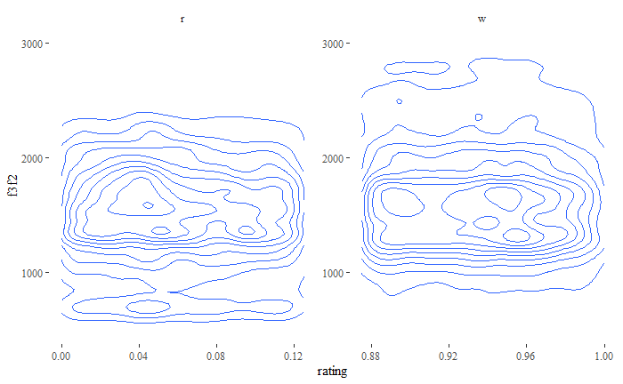

```r
rw.merge %>%
  filter(transc == "r" & rating < 0.125 | transc == "w" & rating > 0.875) %>%
  ggplot() +
  aes(x = rating, y = f3f2) +
  geom_density_2d() +
  scale_y_continuous(limits=c(500,3000)) +
  scale_colour_manual(values=cbPalette) + theme_tufte() +
  facet_wrap(~transc, scales = "free")
```

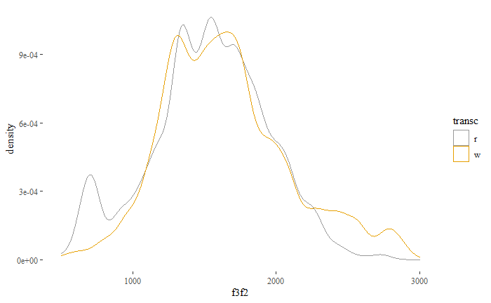

```r
rw.merge %>%
  filter(transc == "r" & rating < 0.125 | transc == "w" & rating > 0.875) %>%
  ggplot() +
  aes(x = f3f2, color = transc) +
  geom_density() +
  scale_colour_manual(values=cbPalette) + theme_tufte() +
  scale_x_continuous(limits=c(500,3000))
```

Looks like very low f3f2 are more likely to be R, very high are W, in the middle, no difference.

### F3 only

What about just for f3?

```
Removed 895 rows containing non-finite values (stat_density2d).Removed 314 rows containing non-finite values (stat_density2d).Removed 61 rows containing non-finite values (stat_density2d).Removed 418 rows containing non-finite values (stat_density2d).
```

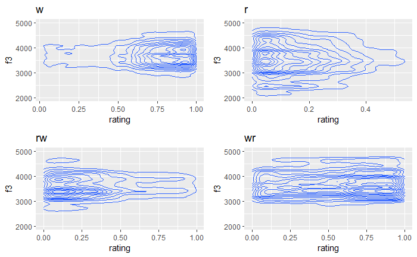

```r
f1=ggplot(data=(rw.merge %>% filter(transc=="w")), aes(y=f3, x=rating)) +
  labs(title="w") +
  geom_density_2d() +
  scale_y_continuous(limits=c(2000,5000))
f2=ggplot(data=(rw.merge %>% filter(transc=="r")), aes(y=f3, x=rating)) +
  labs(title="r") +
  geom_density_2d() +
  scale_y_continuous(limits=c(2000,5000))
f3=ggplot(data=(rw.merge %>% filter(transc=="rw")), aes(y=f3, x=rating)) +
  labs(title="rw") +
  geom_density_2d() +
  scale_y_continuous(limits=c(2000,5000))
f4=ggplot(data=(rw.merge %>% filter(transc=="wr")), aes(y=f3, x=rating)) +
  labs(title="wr") +
  geom_density_2d() +
  scale_y_continuous(limits=c(2000,5000))
ggarrange(f1, f2, f3, f4)
```

F3 distances within a transcription are not related to the rating. But, super low f3 is more likely to be r than the others.

What about f distances by transcription?

```
Removed 1295 rows containing non-finite values (stat_density).Removed 1530 rows containing non-finite values (stat_density).Removed 1525 rows containing non-finite values (stat_density).Removed 1295 rows containing non-finite values (stat_density).
```

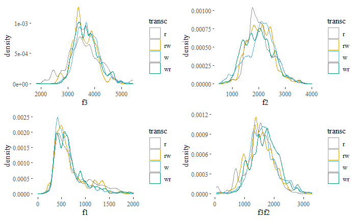

```r
q1=ggplot(data=(rw.merge %>% filter(!is.na(transc))), aes(x=f3, color=transc))+geom_density() +
  scale_colour_manual(values=cbPalette) + theme_tufte()
q2=ggplot(data=(rw.merge %>% filter(!is.na(transc))), aes(x=f2, color=transc))+geom_density() +
  scale_colour_manual(values=cbPalette) + theme_tufte() +
    scale_x_continuous(limits=c(500,4000))
q3=ggplot(data=(rw.merge %>% filter(!is.na(transc))), aes(x=f1, color=transc))+geom_density() +
  scale_colour_manual(values=cbPalette) + theme_tufte()  +
    scale_x_continuous(limits=c(0,2000))
q4=ggplot(data=(rw.merge %>% filter(!is.na(transc))), aes(x=f3f2, color=transc))+geom_density() +
  scale_colour_manual(values=cbPalette) + theme_tufte()
ggarrange(q1, q2, q3, q4)
```

No clear differences…. Maybe some slight ones, like wr for f3f2. Or w for f2. Or r for f3.

### Vowel?

Front/Back Vowel influence on F2?

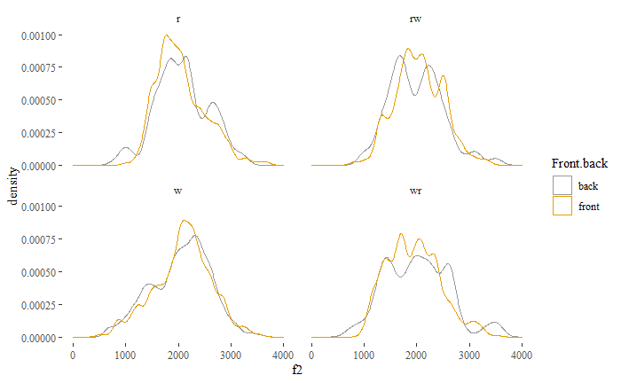

```r
ggplot(data=(rw.merge %>% filter(Front.back==c("back","front"), !is.na(transc))), aes(x=f2, color=Front.back))+geom_density() +
  scale_colour_manual(values=cbPalette) + theme_tufte() +
  facet_wrap(~transc)+
  scale_x_continuous(limits=c(0,4000))
```

Says something about how the r and w is produced independently of the vowel.

Vowel letter influence on F3F2, for R, back vowels?

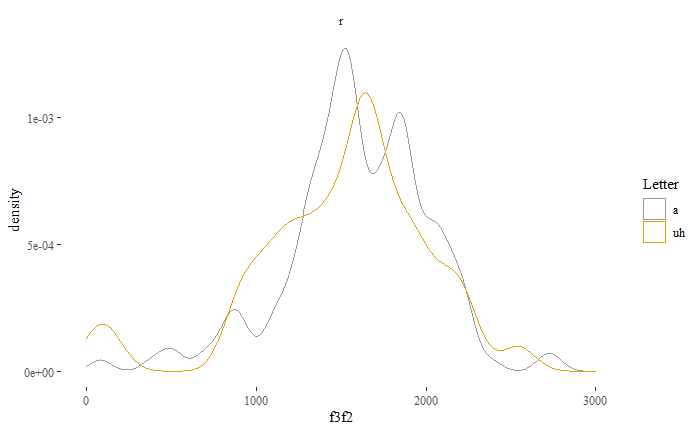

```r
ggplot(data=(rw.merge %>% filter(transc=="r", Letter!="ei", Front.back=="back")), aes(x=f3f2, color=Letter))+geom_density() +
  scale_colour_manual(values=cbPalette) + theme_tufte() +
  facet_wrap(~transc)+
  scale_x_continuous(limits=c(0,3000))
```

Vowel letter influence on F3F2, for R, front vowels?

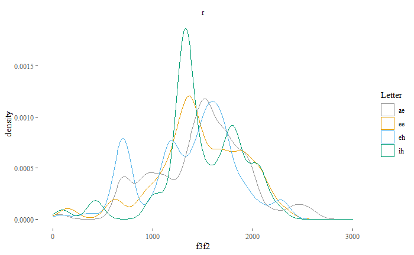

```r
ggplot(data=(rw.merge %>% filter(transc=="r", Letter!="ei", Front.back=="front")), aes(x=f3f2, color=Letter))+geom_density() +
  scale_colour_manual(values=cbPalette) + theme_tufte() +
  facet_wrap(~transc)+
  scale_x_continuous(limits=c(0,3000))
```